# A3: SPL Library Checkouts

2023-03-03

### The Dataset

This data was collected and published by Seattle Public Libraries. Parameters include whether the item is physical or digital, the type of material used, the year and month of the checkout, the number of checkouts, the title, the creator, the subjects, the publisher, and the publication year. The checkout data between 2005 and 2017 were collected from an artwork titled “Making the Invisible Visible”, an artwork that recorded anonymous checkout information from all Library locations in Seattle. After 2017, the checkout information was collected by Seattle Public Libraries as the checkouts happened. The data was initially collected for the artwork, and was later collected to be realeased to the public. One ethical question to consider would be about the validity of the publication details of the library items.

Some possible limitations with this data is that they cannot wholly reflect the media trends and popularity for a multitude of reasons. First of all, there are certain demographics that are more likely to check out materials from the library rather than purchase them, which could lead to skewed results. It is possible, for example, that the elderly and children may be more likely to visit the library compared to teens and adults. The trends could also possibly reflect trends relatively well among lower-income households, but not reflect trends among upper-income households as accurately. Second, there may be some media forms that people are more inclined to purchase, and some media forms that people are more inclined to borrow. Third, the data is only from public libraries within the city of Seattle, and the trends may differ significantly based on location. One problem that may occur when collecting and sorting data could be that the Subjects category is highly diverse, and extremely specific. There is no broader “genre” column with a specific set of possible genres. Because of this, sorting checkouts by the item’s content may prove difficult. There is a similar issue with the Author category, because there are many ways to format the exact same author’s name. Because of this, it may be difficult to plot an author’s popularity without accidentally excluding some of their works.

### First Trends Over Time Chart

This chart shows the trends of the genres romance and mystery since the year 2005. Overall, romance is checked out much more often up until around the year 2021, where mystery takes a lead. One possible explanation for this could be because of the Covid-19 pandemic, where genres such as suspense, mystery, sci-fi, and crime boosted in popularity. It could reflect the feeling of unrest and uncertainty that many people were feeling. Both mystery and romance reach their peak around 2022.

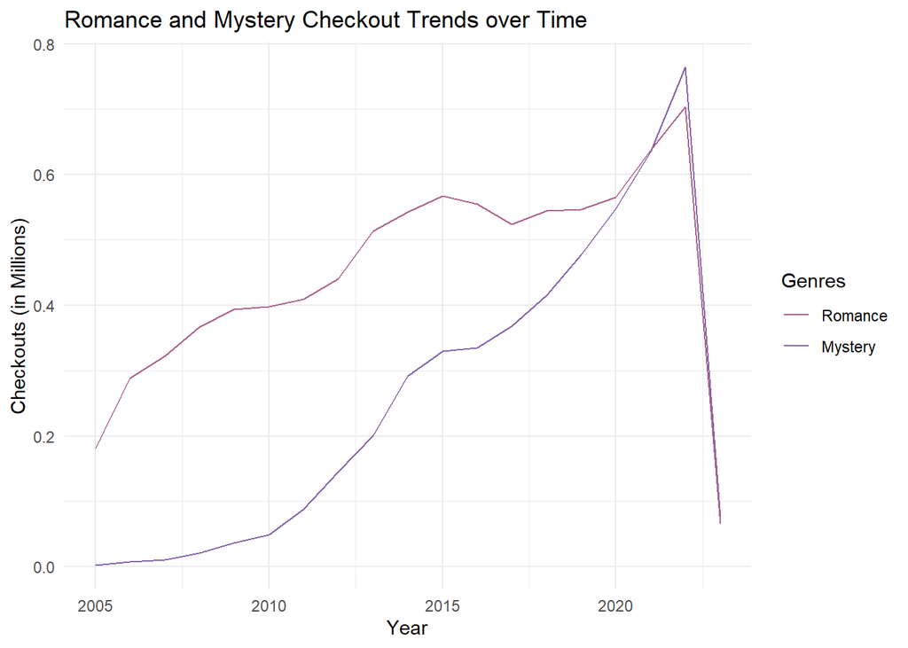

### Second Trends Over Time Chart

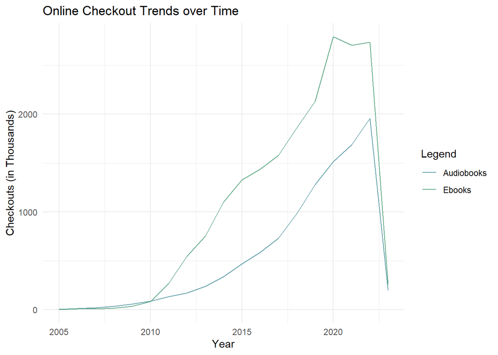

### Your Choice

The last chart is a bar chart that shows the number of checkouts of Harry Potter books throughout the years. The number of checkouts spikes significantly in the year 2020, with very high numbers of checkouts throughout the years 2016 and 2022. There could be a few reasons for this significant increase in popularity so long after the release. One potential reason could be that many people went back to read the books during the Covid-19 pandemic in search for nostalgia. Another possibility could be the announcement of the release of the Harry Potter Legacy video game, which happened some time around 2019. Perhaps many Harry Potter fans wanted to reread the series before playing the video game.

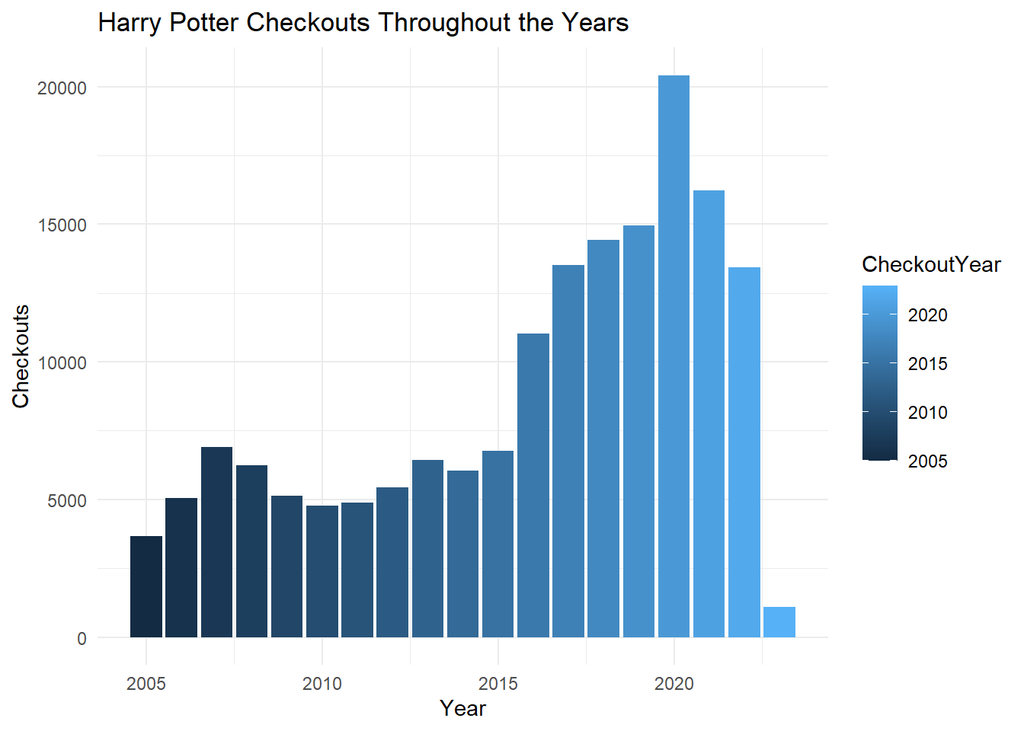